# Controle de qualidade, pré-processamento e clusterização de dados espaciais

Flávio Gabriel Carazza-Kessler

Carolina Saibro-Girardi

2026-09-06

# 1 Visão geral

Nesta vinheta, duas seções sagitais de cérebro de camundongo produzidas com a tecnologia Visium são carregadas do conjunto `stxBrain`, reunidas em um objeto Seurat e submetidas a um fluxo direto de:

1. controle de qualidade dos spots;
2. normalização com `SCTransform()`;
3. redução de dimensionalidade;
4. clusterização não supervisionada; e
5. visualização dos clusters e de genes marcadores no tecido.

Ao final, o objeto processado será salvo como `data/brain.RDS`. Todas as figuras serão gravadas em formato PNG na pasta `imagens/`.

# 2 Preparar o ambiente

## 2.1 Definir as pastas de saída

Antes de executar o código, defina o diretório de trabalho como a pasta `vinhetas/`. No RStudio, use **Session > Set Working Directory > To Source File Location**. Em seguida, execute:

```r
diretorio_vinhetas <- getwd()
diretorio_curso <- dirname(diretorio_vinhetas)
diretorio_dados <- file.path(diretorio_curso, "data")
diretorio_imagens <- file.path(diretorio_curso, "imagens")

dir.create(diretorio_dados, showWarnings = FALSE, recursive = TRUE)
dir.create(diretorio_imagens, showWarnings = FALSE, recursive = TRUE)
```

## 2.2 Carregar os pacotes

```r
library("Seurat")
library("SeuratData")
```

```r
library("sctransform")
library("ggplot2")
library("patchwork")
```

O conjunto `stxBrain` e as demais dependências são instalados exclusivamente em `Configuracao_do_ambiente_RStudio.Rmd`. Depois de executar a primeira vinheta e reiniciar a sessão do R, use o bloco abaixo apenas para confirmar que o conjunto está disponível.

```r
if (!requireNamespace("stxBrain.SeuratData", quietly = TRUE)) {
  stop(
    "O conjunto stxBrain não está instalado. Execute primeiro ",
    "Configuracao_do_ambiente_RStudio.Rmd."
  )
}

message("O conjunto stxBrain está instalado.")
```

```
#> O conjunto stxBrain está instalado.
```

# 3 Carregar e reunir as seções espaciais

Serão utilizadas uma seção anterior e uma seção posterior do cérebro de camundongo.

```r
brain1 <- SeuratData::LoadData("stxBrain", type = "anterior1")
```

```
#> Validating object structure
#> Updating object slots
#> Ensuring keys are in the proper structure
#> Ensuring keys are in the proper structure
#> Ensuring feature names don't have underscores or pipes
#> Updating slots in Spatial
#> Updating slots in anterior1
#> Updated Centroids object 'centroids' in FOV 'anterior1'
#> Updated boundaries in FOV 'anterior1'
#> Validating object structure for Assay5 'Spatial'
#> Validating object structure for VisiumV2 'anterior1'
#> Object representation is consistent with the most current Seurat version
```

```r
brain2 <- SeuratData::LoadData("stxBrain", type = "posterior1")
```

```
#> Validating object structure
#> Updating object slots
#> Ensuring keys are in the proper structure
#> Ensuring keys are in the proper structure
#> Ensuring feature names don't have underscores or pipes
#> Updating slots in Spatial
#> Updating slots in posterior1
#> Updated Centroids object 'centroids' in FOV 'posterior1'
#> Updated boundaries in FOV 'posterior1'
#> Validating object structure for Assay5 'Spatial'
#> Validating object structure for VisiumV2 'posterior1'
#> Object representation is consistent with the most current Seurat version
```

```r
brain <- merge(brain1, brain2)
brain
```

```
#> An object of class Seurat
#> 31053 features across 6049 samples within 1 assay
#> Active assay: Spatial (31053 features, 0 variable features)
#>  2 layers present: counts.anterior1, counts.posterior1
#>  2 spatial fields of view present: anterior1 posterior1
```

A coluna `region`, incluída no conjunto de dados, identifica a região anatômica associada a cada spot. Com o código abaixo é possível identificar o número de spots em cada região (2696 na anterior e 3353 na posterior)

```r
table(brain$region)
```

```
#>
#>  anterior posterior
#>      2696      3353
```

Número de features (genes) identificados no objeto brain (anterior+posterior):

```r
dim(brain)[1]
```

```
#> [1] 31053
```

```r
#31053
```

# 4 Controle de qualidade dos spots

As métricas principais são:

- `nCount_Spatial`: número total de transcritos detectados no spot;
- `nFeature_Spatial`: número de genes detectados; e
- `percent.mt`: porcentagem de transcritos provenientes de genes mitocondriais.

```r
brain[["percent.mt"]] <- Seurat::PercentageFeatureSet(
  brain,
  pattern = "^mt-"
)
```

## 4.1 Número de transcritos

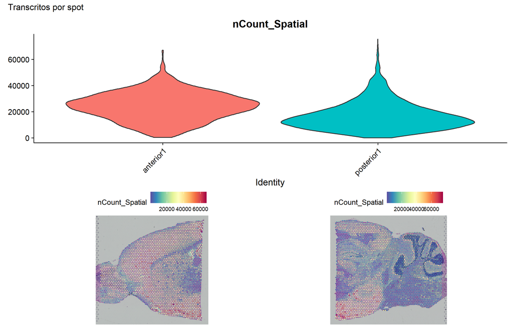

```r
vln_contagens <- VlnPlot(
  brain,
  features = "nCount_Spatial",
  pt.size = 0
) + NoLegend()

mapa_contagens_anterior <- SpatialFeaturePlot(
  brain,
  features = "nCount_Spatial",
  images = "anterior1"
)

mapa_contagens_posterior <- SpatialFeaturePlot(
  brain,
  features = "nCount_Spatial",
  images = "posterior1"
)

painel_contagens <- vln_contagens /
  (mapa_contagens_anterior | mapa_contagens_posterior) +
  plot_annotation(title = "Transcritos por spot")

painel_contagens
```

```r
ggsave(
  filename = file.path(diretorio_imagens, "Brain_SpotQC_contagens.png"),
  plot = painel_contagens,
  width = 11,
  height = 7,
  units = "in",
  dpi = 120,
  bg = "white"
)
```

## 4.2 Número de genes

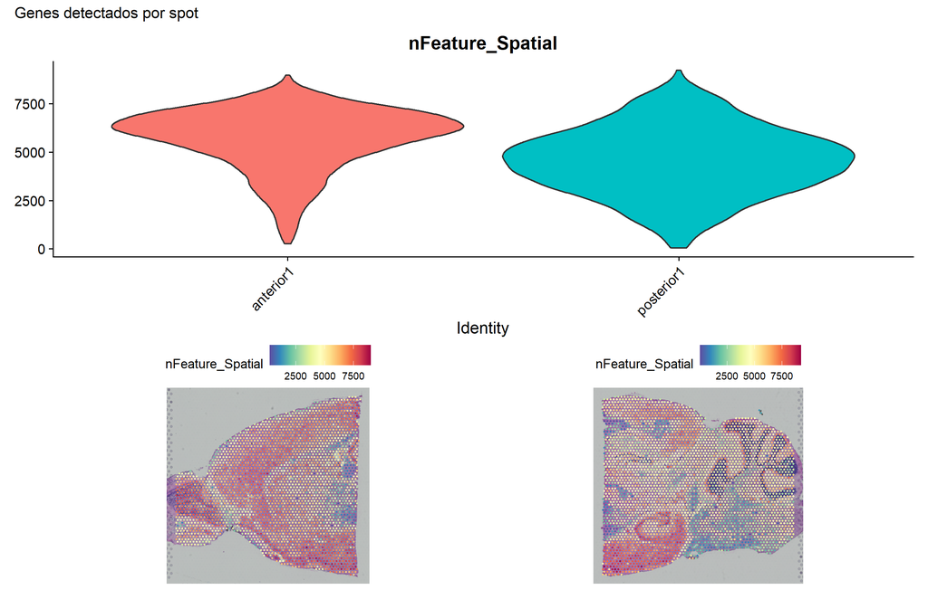

```r
vln_genes <- VlnPlot(
  brain,
  features = "nFeature_Spatial",
  pt.size = 0
) + NoLegend()

mapa_genes_anterior <- SpatialFeaturePlot(
  brain,
  features = "nFeature_Spatial",
  images = "anterior1"
)

mapa_genes_posterior <- SpatialFeaturePlot(
  brain,
  features = "nFeature_Spatial",
  images = "posterior1"
)

painel_genes <- vln_genes /
  (mapa_genes_anterior | mapa_genes_posterior) +
  plot_annotation(title = "Genes detectados por spot")

painel_genes
```

```r
ggsave(
  filename = file.path(diretorio_imagens, "Brain_SpotQC_genes.png"),
  plot = painel_genes,
  width = 11,
  height = 7,
  units = "in",
  dpi = 120,
  bg = "white"
)
```

## 4.3 Porcentagem mitocondrial

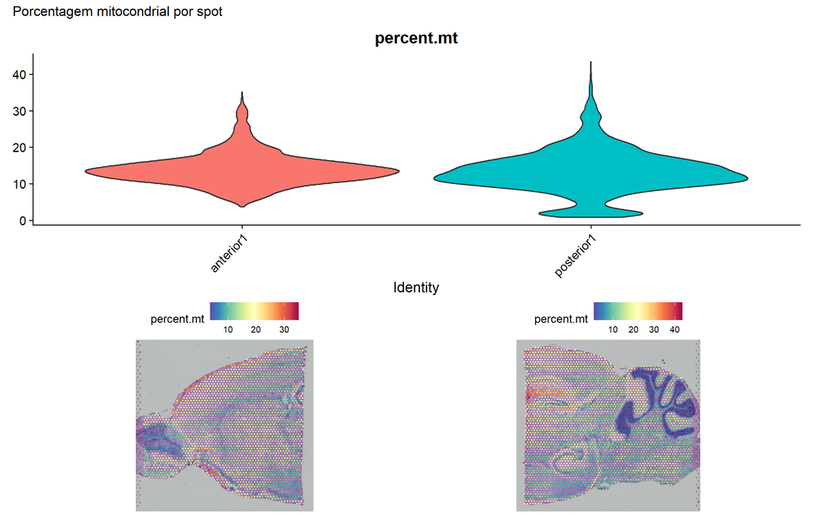

```r
vln_mitocondrial <- VlnPlot(
  brain,
  features = "percent.mt",
  pt.size = 0
) + NoLegend()

mapa_mt_anterior <- SpatialFeaturePlot(
  brain,
  features = "percent.mt",
  images = "anterior1"
)

mapa_mt_posterior <- SpatialFeaturePlot(
  brain,
  features = "percent.mt",
  images = "posterior1"
)

painel_mitocondrial <- vln_mitocondrial /
  (mapa_mt_anterior | mapa_mt_posterior) +
  plot_annotation(title = "Porcentagem mitocondrial por spot")

painel_mitocondrial
```

```r
ggsave(
  filename = file.path(diretorio_imagens, "Brain_SpotQC_mitocondrial.png"),
  plot = painel_mitocondrial,
  width = 11,
  height = 7,
  units = "in",
  dpi = 120,
  bg = "white"
)
```

Neste conjunto didático, o perfil das métricas é utilizado para inspeção e nenhum limiar adicional de filtragem será aplicado.

Caso você queira filtrar de acordo com alguma parâmetro dos metadados, corra o código abaixo. Para essa vinheta, ele é OPCIONAL, então é possível pulá-lo. Nessa exemplo é aplicado um filtro que passam apenas spots que tenham mais de 200 genes identificados; que possuam mais de 500 counts; e que possuam mais de 5% de mitocôndria.

```r
brain_filt <- subset(brain, subset = nFeature_Spatial > 200 &
                       nCount_Spatial > 500 &
                       percent.mt > 5)
print("ANTES DE FILTRAR")
```

```
#> [1] "ANTES DE FILTRAR"
```

```r
print(paste("Número de spots:",dim(brain)[2]))
```

```
#> [1] "Número de spots: 6049"
```

```r
print(paste("Número de genes:",dim(brain)[1]))
```

```
#> [1] "Número de genes: 31053"
```

```r
table(brain$region)
```

```
#>
#>  anterior posterior
#>      2696      3353
```

```r
print("DEPOIS DE FILTRAR")
```

```
#> [1] "DEPOIS DE FILTRAR"
```

```r
print(paste("Número de spots:",dim(brain_filt)[2]))
```

```
#> [1] "Número de spots: 5740"
```

```r
print(paste("Número de genes:",dim(brain_filt)[1]))
```

```
#> [1] "Número de genes: 31053"
```

```r
table(brain_filt$region)
```

```
#>
#>  anterior posterior
#>      2685      3055
```

Com esse exemplo, foram excluídos 11 spots da região anterior e 298 da região posterior. Para comparar os novos parâmetros, rode os gráficos acima com o dado filtrado `brain_filt`.

# 5 Pré-processamento e clusterização

`SCTransform()` normaliza os dados e estabiliza a variância. Em seguida, os componentes principais são utilizados para construir UMAP, t-SNE, grafo de vizinhança e clusters.

Essas etapas são as mais demoradas da vinheta, principalmente SCTransform(). Curiosidade: ao rodar, será mostrado o tempo que levou para rodar as análises no seu computador.

```r
set.seed(20260906)

inicio <- Sys.time()

brain <- SCTransform(
  brain,
  assay = "Spatial",
  do.scale = TRUE,
  return.only.var.genes = FALSE,
  verbose = FALSE
)

fim <- Sys.time()
tempo <- fim - inicio
tempo
```

```
#> Time difference of 1.566451 mins
```

```r
inicio <- Sys.time()

brain <- RunPCA(brain, verbose = FALSE)
brain <- RunUMAP(brain, dims = 1:10)
brain <- RunTSNE(brain, dims = 1:10)
brain <- FindNeighbors(brain, dims = 1:10)
brain <- FindClusters(brain, verbose = FALSE)

fim <- Sys.time()
tempo <- fim - inicio
tempo
```

```
#> Time difference of 53.71796 secs
```

O objeto processado é salvo na pasta `data/`, onde poderá ser reutilizado nas análises seguintes do curso.

```r
saveRDS(
  brain,
  file = file.path(diretorio_dados, "brain.RDS")
)
```

# 6 Visualizar os clusters

## 6.1 UMAP e t-SNE

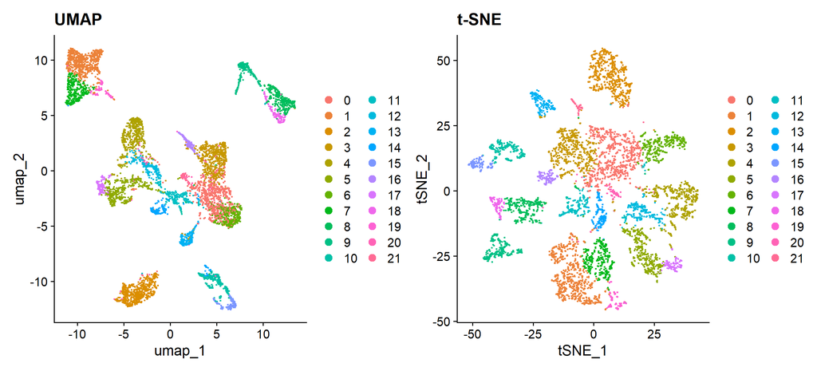

```r
umap_brain <- DimPlot(brain, reduction = "umap") +
  labs(title = "UMAP")

tsne_brain <- DimPlot(brain, reduction = "tsne") +
  labs(title = "t-SNE")

painel_reducoes <- umap_brain | tsne_brain
painel_reducoes
```

```r
ggsave(
  filename = file.path(diretorio_imagens, "Brain_clustering_reducoes.png"),
  plot = painel_reducoes,
  width = 11,
  height = 5,
  units = "in",
  dpi = 120,
  bg = "white"
)
```

## 6.2 Distribuição espacial

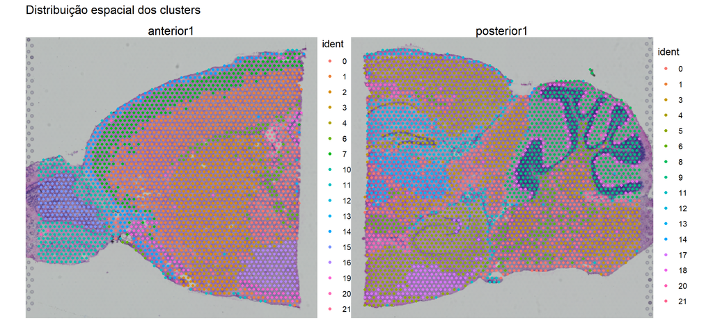

```r
mapa_clusters <- SpatialDimPlot(brain) +
  plot_annotation(title = "Distribuição espacial dos clusters")

mapa_clusters
```

```r
ggsave(
  filename = file.path(diretorio_imagens, "Brain_clustering_espacial.png"),
  plot = mapa_clusters,
  width = 11,
  height = 5,
  units = "in",
  dpi = 120,
  bg = "white"
)
```

## 6.3 Composição das seções

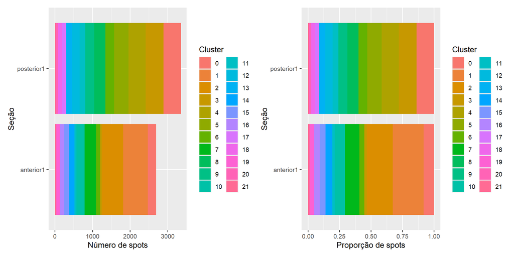

```r
distribuicao_clusters <- as.data.frame(
  table(brain$seurat_clusters, brain$orig.ident)
)
colnames(distribuicao_clusters) <- c("Cluster", "Secao", "Spots")

p_numero_spots <- ggplot(
  distribuicao_clusters,
  aes(x = Secao, y = Spots, fill = Cluster)
) +
  geom_col() +
  coord_flip() +
  labs(x = "Seção", y = "Número de spots")

p_proporcao_spots <- ggplot(
  distribuicao_clusters,
  aes(x = Secao, y = Spots, fill = Cluster)
) +
  geom_col(position = "fill") +
  coord_flip() +
  labs(x = "Seção", y = "Proporção de spots")

painel_composicao <- p_numero_spots | p_proporcao_spots
painel_composicao
```

```r
ggsave(
  filename = file.path(diretorio_imagens, "Brain_clustering_composicao.png"),
  plot = painel_composicao,
  width = 10,
  height = 5,
  units = "in",
  dpi = 120,
  bg = "white"
)
```

# 7 Visualizar genes representativos

Os genes abaixo destacam populações neuronais e não neuronais presentes no tecido. Sua distribuição ajuda a relacionar os clusters aos compartimentos anatômicos, mas não substitui uma anotação celular completa.

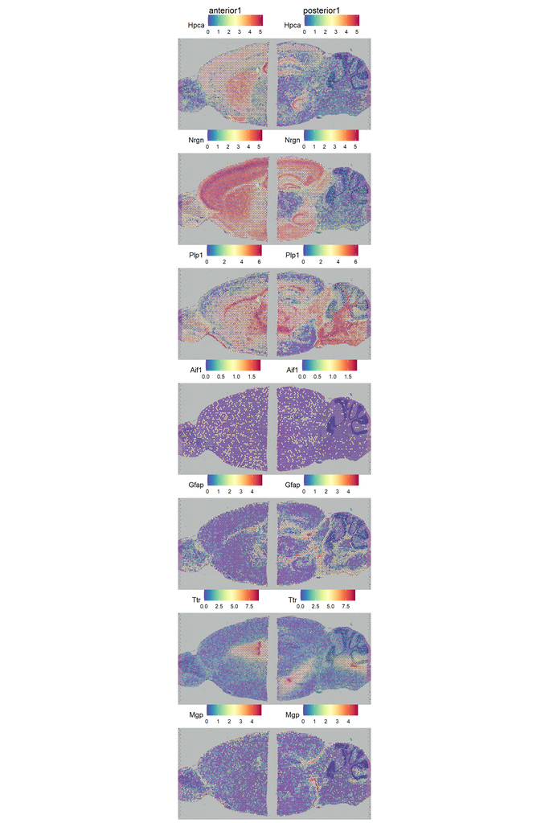

```r
genes <- c(
  "Hpca", "Nrgn", # neurônios
  "Plp1",         # oligodendrócitos
  "Aif1",         # micróglia
  "Gfap",         # astrócitos
  "Ttr",          # células do plexo coroide
  "Mgp"           # fibroblastos
)

painel_genes_marcadores <- SpatialFeaturePlot(
  brain,
  features = genes,
  ncol = 2
)

painel_genes_marcadores
```

```r
ggsave(
  filename = file.path(diretorio_imagens, "Brain_Genes.png"),
  plot = painel_genes_marcadores,
  width = 12,
  height = 18,
  units = "in",
  dpi = 120,
  bg = "white",
  limitsize = FALSE
)
```

# 8 Expressão Diferencial em RNAseq espacial

A função `FindMarkers()` do `Seurat` que realiza um cálculo de expressão diferencial entre dois fatores pré-anotados. Para esse exemplo, serão utilizados dois clusteres que foram calculados anteriormente, a informação de clusteres fica armazenada nos metadados do objeto `Seurat`. A função pode ser utilizada para qualquer fator pré-anotado, isso inclui clusteres, PCs, tipos celulares e afins.

Para prosseguir com o exemplo dessas análises, iremos trabalhar apenas com região `anterior`. Para isso, será feito um subset do objeto `brain`.

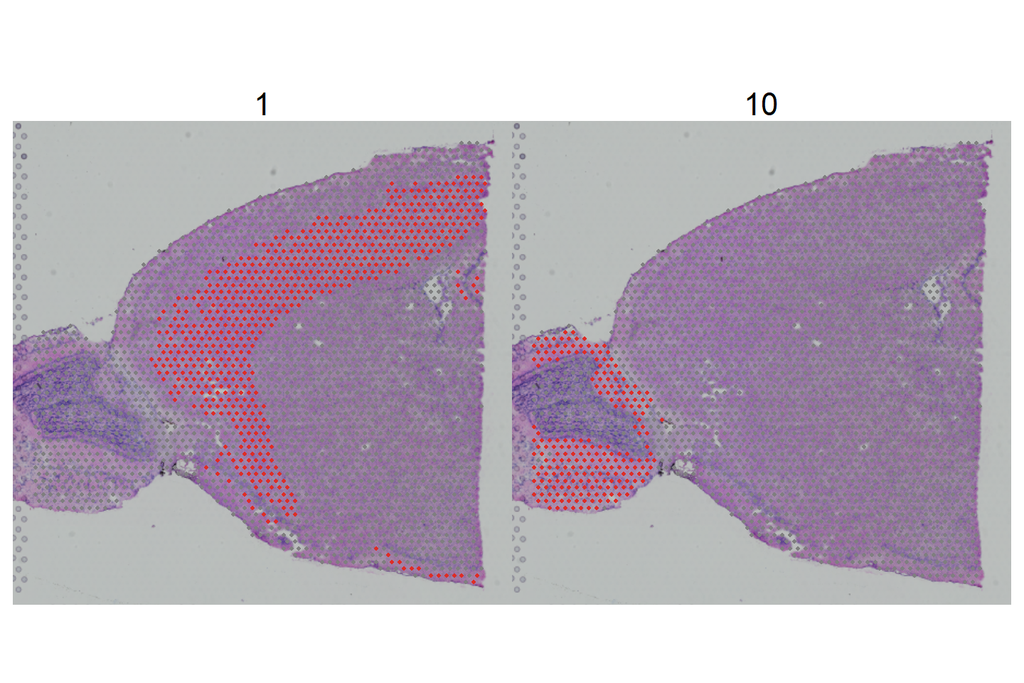

```r
# subset da região
brain_ant <- subset(brain, subset = region == "anterior")

# Foram selecionados os clusteres 1 e 10 para a análise do FindMarkers
SpatialDimPlot(brain_ant,
               cells.highlight = CellsByIdentities(object = brain, idents = c(1,10)),
               facet.highlight = TRUE,ncol = 2)
```

```r
# Prepara os diferentes modelos SCT para expressão diferencial
brain_ant <- PrepSCTFindMarkers(
  brain_ant,
  assay = "SCT"
)
```

```
#> Only one SCT model is stored - skipping recalculating corrected counts
```

```r
# Procura "marcadores" das regiões selecionadas
de_markers <- FindMarkers(
  brain_ant,
  ident.1 = "1",
  ident.2 = "10",
  assay = "SCT"
)

de_markers
```

```
#>                       p_val avg_log2FC pct.1 pct.2     p_val_adj
#> Th            1.197076e-125 -5.1906743 0.134 0.923 2.183467e-121
#> Cdhr1         1.759011e-121 -4.7914924 0.269 0.977 3.208437e-117
#> Calb2         2.277674e-121 -4.8344695 0.379 1.000 4.154478e-117
#> Doc2g         2.411722e-115 -4.9163413 0.334 0.973 4.398981e-111
#> Eomes         2.880458e-110 -5.4674543 0.067 0.786 5.253956e-106
#> Chn1          3.830352e-108  2.0753779 1.000 1.000 6.986563e-104
#> Nrgn          7.357113e-108  2.9559248 1.000 0.982 1.341937e-103
#> Dbi           5.626423e-106 -1.7840057 1.000 1.000 1.026260e-101
#> Enc1          1.160364e-105  2.9632852 1.000 0.705 2.116505e-101
#> Slc6a11       1.176621e-105 -3.1801906 0.680 0.991 2.146158e-101
#> Camk2n1       3.970366e-105  1.7969147 1.000 1.000 7.241948e-101
#> Pcp4l1        4.258540e-105 -2.6370548 0.829 1.000 7.767576e-101
#> Fabp7         3.434156e-104 -4.4966520 0.659 1.000 6.263901e-100
#> Snap25        3.964352e-104  1.2876076 1.000 1.000 7.230977e-100
#> 1110008P14Rik 3.539093e-103  1.9787013 1.000 0.995  6.455306e-99
#> Cst3          5.566248e-102 -1.0246350 1.000 1.000  1.015284e-97
#> Vsnl1         7.334392e-101  1.8180730 1.000 0.982  1.337793e-96
#> Zic1          8.601735e-101 -4.2537107 0.105 0.805  1.568956e-96
#> Apoe          2.431746e-100 -1.8319763 1.000 1.000  4.435504e-96
#> Lingo1         1.149378e-99  2.1149719 1.000 0.868  2.096465e-95
#> Ppp3ca         1.299832e-99  1.7064150 1.000 0.991  2.370893e-95
#> Shisa8         1.378803e-99 -3.7487849 0.211 0.891  2.514936e-95
#> Calm2          2.067934e-99  1.0366089 1.000 1.000  3.771912e-95
#> Nmb            5.834229e-99 -4.3017157 0.194 0.873  1.064163e-94
#> Arpp19         2.722987e-98  1.8525317 1.000 0.959  4.966728e-94
#> Csdc2          3.963519e-98 -2.1351552 0.841 1.000  7.229458e-94
#> Ywhah          7.509289e-98  1.2141234 1.000 1.000  1.369694e-93
#> Ckb            9.581042e-98 -0.7320250 1.000 1.000  1.747582e-93
#> Ppp3r1         1.751799e-97  1.4877925 1.000 0.995  3.195282e-93
#> Tuba4a         5.037270e-97  1.3779733 1.000 0.991  9.187981e-93
#> Selenow        2.185931e-96  0.9570027 1.000 1.000  3.987138e-92
#> Clstn1         4.017331e-96  1.1264543 1.000 1.000  7.327612e-92
#> Prkcb          2.586482e-95  1.6889000 1.000 0.959  4.717743e-91
#> 3110035E14Rik  2.866584e-95  3.7024058 0.968 0.532  5.228649e-91
#> Zfp365         3.431721e-95  1.8279666 1.000 0.900  6.259459e-91
#> Ms4a15         1.231240e-94 -4.9544561 0.071 0.732  2.245782e-90
#> Calm1          1.805794e-94  0.6823986 1.000 1.000  3.293768e-90
#> Mal2           5.426153e-94  3.2709356 0.967 0.409  9.897303e-90
#> Sp8            2.696889e-93 -4.5166326 0.068 0.718  4.919125e-89
```

[output cut: 147 more lines]

```
#> Scg2           1.192722e-59 -1.4510815 0.961 1.000  2.175525e-55
#> Hmgn1          1.477069e-59 -1.4567722 0.813 0.986  2.694174e-55
#> Scgn           1.532577e-59 -4.2359089 0.041 0.491  2.795420e-55
#> Nppa           1.000146e-58 -4.7649783 0.018 0.427  1.824267e-54
#> Nptx1          1.329073e-58  1.8005856 0.974 0.791  2.424230e-54
#> Atp1a1         1.773663e-58  0.8550472 1.000 1.000  3.235161e-54
#> Efhd2          1.981654e-58  1.2520935 0.997 0.955  3.614537e-54
#> Apod           2.036020e-58 -2.9483799 0.750 0.977  3.713700e-54
#> Egr3           2.939782e-58  2.2237210 0.897 0.386  5.362163e-54
#> Glul           4.487785e-58 -0.9635172 1.000 1.000  8.185719e-54
#> Gm11549        1.175071e-57  2.9169205 0.810 0.182  2.143330e-53
#> Ppm1j          1.304398e-57 -4.0589240 0.049 0.500  2.379223e-53
#> Homer1         1.380894e-57  1.5463850 0.976 0.795  2.518750e-53
#> Fam171b        1.726346e-57 -1.1813607 0.989 1.000  3.148856e-53
#>  [ reached 'max' / getOption("max.print") -- omitted 11069 rows ]
```

O data frame `de_markers` obtido elenca os genes diferencialmente expressos entre os fatores fornecidos, nesse caso dois clusteres. As colunas indicam:

- p_val : p-valor
- avg_log2FC : log fold-change da expressão média entre os dois “grupos”. Valores positivos indicam que o feature (gene) está mais expresso no primeiro grupo. Valores negativos indicam que o feature (gene) está mais expresso no segundo grupo.
- pct.1 : O percentual de células em que o feature (gene) é detectado no primeiro grupo
- pct.2 : O percentual de células em que o feature (gene) é detectado no segundo grupo
- p_val_adj : p-valor ajustado, o ajuste é realizado com a correção de bonferroni usando todos os features do dataset.

Encontre mais informações sobre a função `FindMarkers()` na vinheta do `Seurat`: [Differential expression testing](https://satijalab.org/seurat/articles/de_vignette).

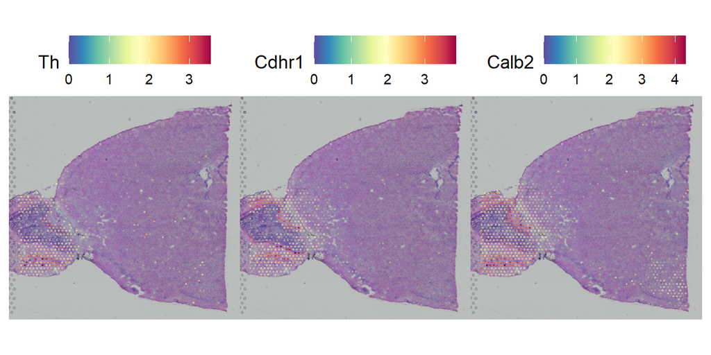

```r
g <- SpatialFeaturePlot(object = brain_ant,
                        features = rownames(de_markers)[1:3],
                        alpha = c(0.1, 1), ncol = 3)

g
```

```r
# Salvar figura
ggsave(
  filename = file.path(diretorio_imagens, "FindMarkers.png"),
  plot = g,
  width = 6,
  height = 3,
  units = "in",
  dpi = 120,
  bg = "white",
  limitsize = FALSE
)
```

A imagem gerada apresenta três genes diferencialmente expressos do cluster 10 em relação ao cluster 1, ou seja, genes que estão enriquecidos no cluster 10.